# TWD - Homework 2

Aleksandra Kwiatkowska

2023-11-04

### Niepoprawny wykres

Dnia 03-11-2023 portal gramywzielone.pl skupiający się na tematyce źródeł odnawialnych, opublikował artykuł dotyczący globalnych trendów energetycznych, w którym zamieścił poniższy wykres przedstawiający zmiany w produkcji energii z wykorzystaniem poszczególnych technologii w krajach Unii Europejskiej w latach 2010-2022.

Source: https://www.gramwzielone.pl/trendy/20168174/ponad-20-krotny-wzrost-fotowoltaiki-do-2050

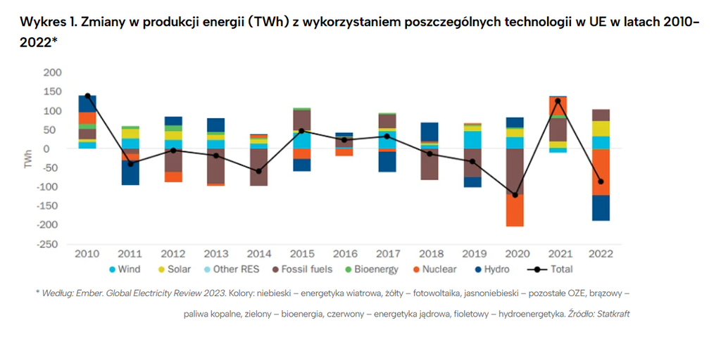

### Elementy wymagające poprawy

- Na orginalnym wykresie poszczególne technologie są oznaczone innymi kolorami, ale umieszczone w jednym słupku, co znacząco utrudnia porównanie jak zmieniła się ilość produkowanej energii z użyciem energii słonecznej, wiatrowej itd. na przestrzeni lat.
- Zmiana produkcja przyjmuje w jednych latach wartości dodatnie, a w innych ujemne co sprawia, że kolory nie zawsze są w tej samej kolejności co stanowi dodatkowe utrudnienie w analizowaniu wykresu i sparwia, że jest on chotyczny.
- Na wykresie brakuje również poziomych lini pomocniczych, które ułatwiałyby odczytywanie przybliżonych wartości, do których sięgają słupki.
- Linia zaznaczająca sumaryczną zmianę produkcji energii, która jest nałożona na cały wykres jest nieczytelna i nie pozwala wygodnie oszacować jak zmieniała się produkcja energii, ze wzgędu na dużą ilość kolorów i informacji, którą autorzy chcieli zawrzeć na tym wykresie.

### Kod pozwalający stworzyć poprawny wykres

```r
#Stworzenie tabeli danych

Energy <- c("Wind", "Solar", "Other RES", "Fossil fules", "Bioenergy", "Nuclear", "Hydro")
rok_2010 <- c(15, 5, 0.5, 30, 10, 40, 50)
rok_2011 <- c(30, 27, 1, -10, 3, -10, - 90)
rok_2012 <- c(28, 25, 2, -65, 7, -20, 25)
rok_2013 <- c(33, 10, 0.5, -100, 7, -5, 40)
rok_2014 <- c(22, 10, 0.5, -110, 2, 3, 1)
rok_2015 <- c(40, 5, 1, 50, 3, -30, -40)
rok_2016 <- c(4, 1, 0, 30, 1, -20, 5)
rok_2017 <- c(42, 4, 1, 35, 3, -5, - 60)
rok_2018 <- c(10, 0.5, 2, -90, 4, 5, 60)
rok_2019 <- c(45, 10, 1, -86, 3, 2, -20)
rok_2020 <- c(35, 25, 1, -120, 2, -90, 20)
rok_2021 <- c(-10, 20, 0, 50, 6, 38, 2)
rok_2022 <- c(30, 40, 0, 20, 0, -125, -50)

data <- data.frame(
  Year = rep(2010:2022, each = length(Energy)),
  Energy = rep(Energy, times = 13),
  Value = c(rok_2010, rok_2011, rok_2012, rok_2013, rok_2014, rok_2015,
            rok_2016, rok_2017, rok_2018, rok_2019, rok_2020, rok_2021, rok_2022)
)

# Stworzenie poprawnego wykresu 1
suppressWarnings(library(ggplot2))

kolory <- c( "Wind" = "#87CEFA", "Solar" = "#FCE503", "Other RES" = "#666666", "Fossil fules" = "#8B4513",
             "Bioenergy" = "#008000", "Nuclear" = "#FF8C00", "Hydro" = "#000080")

ggplot(data, aes(x = as.factor(Year), y = Value, fill = Energy)) +
  geom_bar(stat = "identity", position = position_dodge(width = 0.8)) +
  labs(title = "Zmiany w produkcji energii z wykorzystaniem poszczególnych technologii \nw UE w latach 2010-2022",
       x = "",
       y = "Twh") +
  scale_fill_manual(values = kolory) +
  theme_minimal() +
  theme(legend.position = "bottom", plot.title = element_text(size = 13)) -> plot1


# Stworzenie poprawnego wykresu 2
suppressMessages(suppressWarnings(library(dplyr)))

data %>%
  group_by(Year) %>%
  summarise(sum = sum(Value)) %>%
  ggplot(aes(x = Year, y = sum)) +
  geom_line(linewidth = 1.2, color = "#87CEFA") +
  geom_point(size = 2, color = "#0000CD") +
  geom_hline(yintercept = 0, color = "grey15", linewidth = 0.6) +
  scale_x_continuous(breaks = data$Year, labels = as.integer) +
  geom_text(aes(label = sum), hjust = -0.3, vjust = -0.1) +
  labs(
    title = "Zmiany w produkcji energii w UE w latach 2010-2022",
    x = "",
    y = "Zmiana Produkcji Energii (Twh)"
  ) +
  theme_minimal() +
  theme(legend.position = "top", plot.title = element_text(hjust = 0.5, size = 15)) -> plot2
```

### Poprawne wykresy

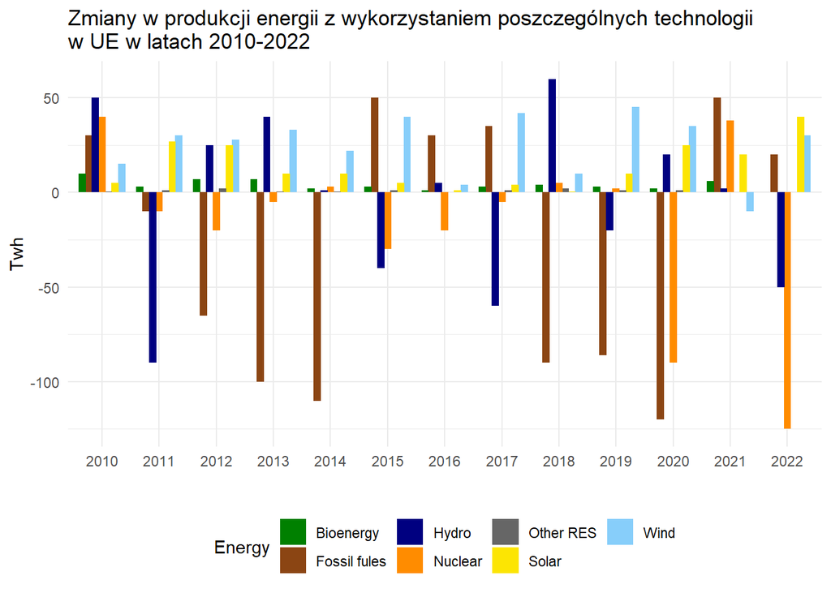

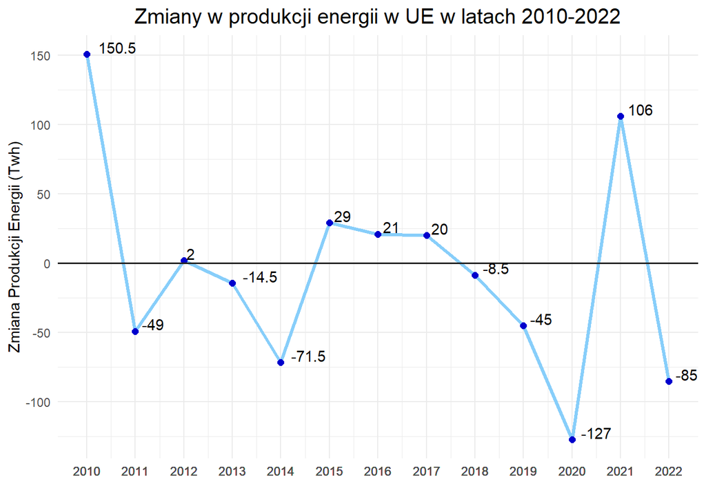

### Uzasadnienie

Na wykresie 1. zmiany dla poszczególnych rodzajów zostały rozdzielone na osobne słupki występujące zawsze w tej samej kolejności, dzięki czemu prościej jest analizować jak napawdę zmieniała się produkcja energii z wykorzystanie różnych technologii. Zostały również dodane linie pomocnicze, które pozwalają z większą precyzją oszacować i porównywać zmiany, Dodatkowo sumaryczna zmiana produkcji energii została umieszczona w czytelny sposób na wykresie 2. z podpisanymi wartościami, dzięki czemu obydwa wykresy są przejrzystrze.